# Data wrangling using the tidyverse

Today we will learn some useful data manipulation functions in R. A lot of this stuff can be done with base R functions, but if you don’t know how to do it in base R, using tidyverse is probably easier to learn! I will be around to help, but please also help each other where possible.

### Resources

There are some useful cheat sheets available at https://rstudio.com/resources/cheatsheets/:  
* Data Import Cheat Sheet * Data Transformation Cheat Sheet * Factors with forcats Cheat Sheet

And this book on R for data science is useful too: http://r4ds.had.co.nz/

### Outline

Here is a list of things we will learn today:

1. Filtering observations using `filter()`
2. Selecting variables using `select()`
3. Changing data from wide to long format and vice versa, using `pivot_longer()` and `pivot_wider()`
4. Merging different dataframes together with the `bind()` and `join()` functions
5. Using the pipe operator `%>%` to write tidy code and group observations with `group_by()`
6. Calculating new variables with `mutate()` and `summarise()`
7. Reordering factor levels for nicer plots

### How we will work today

There are lots of functions in different packages, and altogether they are called tidyverse. The tidyverse packages we will use today are dplyr, tidyr, and forcats, but you can download all of them in one go using `install.packages("tidyverse")`. We will not use every single function, or different way of using them, but instead focus on the main ones that will hopefully come in handy!

I have not included the output of the code here, so you will have to run it yourself :)

> There will be some exercises, formatted like this, so you can get some practice in.

```r
library(tidyverse)
```

We will load in some data first. As it was International Women’s Day on Sunday, we will use data from the Women’s Football World Cups. For a description of the variables see https://github.com/rfordatascience/tidytuesday/tree/master/data/2019/2019-07-09.

This is how to read in the data from github:

```r
wwc_outcomes <- read.csv("https://raw.githubusercontent.com/rfordatascience/tidytuesday/master/data/2019/2019-07-09/wwc_outcomes.csv")
squads <- read.csv("https://raw.githubusercontent.com/rfordatascience/tidytuesday/master/data/2019/2019-07-09/squads.csv")
codes <- read.csv("https://raw.githubusercontent.com/rfordatascience/tidytuesday/master/data/2019/2019-07-09/codes.csv")
```

I usually look at the data to start with, mainly using `str()`, `summary()` or `head()`. To understand what every function does, it might be helpful to run these before and after you have made changes to the data!

We will start using the dataframe `wwc_outcomes`.

```r
str(wwc_outcomes)
summary(wwc_outcomes)
head(wwc_outcomes)
```

> Use the above functions to look at the dataframes `squads` and `codes` too.

The functions follow the normal form in R, for example, we can change column names using `rename()`:

```r
wwc_outcomes2 <- rename(wwc_outcomes, gameID = yearly_game_id)
head(wwc_outcomes2)
```

This can be useful when we read in data with long, complicated column names, for example.

> What do the functions `distinct()` and `arrange()` do? Have a look on the data transformation cheat sheet.

## 1. filter()

One of the simplest and most useful functions is `filter()`.

`filter()` will retain or remove rows in your dataframe, according to conditions you set:

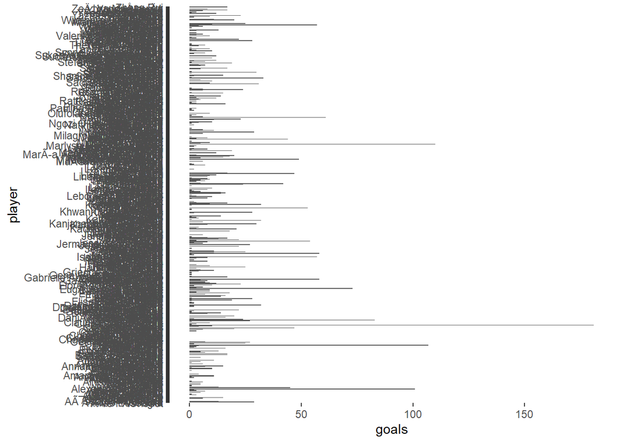

```r
ggplot(data = squads, aes(x = player, y = goals)) +
  geom_col() +
  coord_flip()  # Makes a bar plot with ggplot, but we can't see anything in there as there are so many players!
```

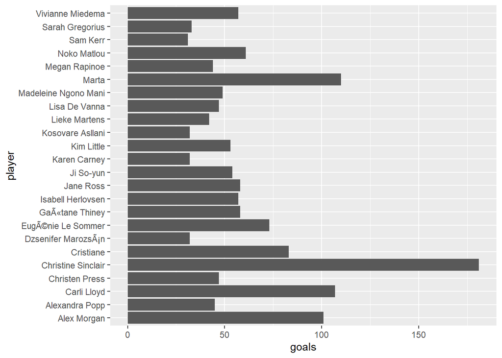

```r
goals30 <- filter(squads, goals > 30)
# this creates a new dataframe called goals30, which are all rows from dataframe squads where variable goals is above 30

ggplot(data = goals30, aes(x = player, y = goals)) +
  geom_col() +
  coord_flip()
```

> Exercise: Create a dataframe from squads where all caps are above 150, and check it worked using `ggplot()`

We can also look for exact values:

```r
filter(wwc_outcomes, score == 13)
## In this case, we will see the output straight away, rather than saving it in a separate dataframe. This is useful if we want to look into our data a bit
```

The structure for NA values is slightly different (`x == NA` doesn’t work):

```r
summary(squads$goals)
# goals contains 32 rows with NA values

goalsNA <- filter(squads, is.na(goals))
# In this case we keep those rows where goals is NA

summary(goalsNA$goals)
```

> Can you create a dataframe where the variable goals is never NA? You cna use the Data Transformation cheat sheet.

> In the wwc_outcomes dataframe, retain only observations where team is ENG (or another team of your choosing).

> Can you also create a new dataframe with three different teams? You might need to use this operator: `%in%`